# Methane and short-chain alkane H isotope data processing for samples obtained in Oman in 2017 and 2018

Source file: OM17-18_CH4_H.Rmd

Daniel Nothaft

11 Aug 2020

# 1 Oman 2017 and 2018 CH$_4$ $\delta^{2}$H - Introduction

CH$_4$ isotopic composition was measured by GC-P-IRMS as described in the methods section of the manuscript. The following code steps through the data processing and calibration to convert measured values to values vs. the international reference standard (Vienna Standard Mean Ocean Water, VSMOW). The gas samples processed in this document were collected in Oman in the February-March 2017 and 2018 field seasons.

# 2 Load libraries

```r
# load libraries
library(tidyverse) # dplyr, tidyr, ggplot
library(isoreader) # reading isotope data files
library(isoprocessor) # processing isotope data files

# global knitting options for automatic saving of all plots as .png and .pdf. Also sets cache directory.
knitr::opts_chunk$set(
  dev = c("png", "pdf"), fig.keep = "all",
  dev.args = list(pdf = list(encoding = "WinAnsi", useDingbats = FALSE)),
  fig.path = file.path("fig_output/", paste0(gsub("\\.[Rr]md", "/", knitr::current_input()))),
  cache.path = file.path("cache/", paste0(gsub("\\.[Rr]md", "/", knitr::current_input())))
)
```

Data processed using the packages [isoreader](http://isoreader.kopflab.org) version 1.2.1 and [isoprocessor](http://isoprocessor.kopflab.org/) version 0.6.7.

# 3 Load Data

```r
# read files
iso_files_raw <-
  file.path(
    "data_raw/OM17-18_CH4_H_data", "OM17-18_CH4_H_data.cf.rds"
  ) %>%
    # read data files in parallel for fast read
  iso_read_continuous_flow(parallel = TRUE)
```

# 4 Process file info & peak table

```r
# process
iso_files <- iso_files_raw %>%
  # set peak table from vendor data table
  iso_set_peak_table_from_auto_vendor_data_table() %>%
  # rename key file info columns
  iso_rename_file_info(id1 = `Identifier 1`, inject_type = `Identifier 2`) %>%
  # parse text info into numbers
  iso_parse_file_info(number = Analysis) %>%
  # process other file information that is specific to the naming conventions
  # of this particular sequence
  iso_mutate_file_info(
    # what was the injection volume?
    inject_volume = parse_number(Comment) %>% iso_double_with_units("uL"),
    # what folder are the data files in? (assuming folder = sequence)
    folder = basename(dirname(file_path))
  )
```

```
## Info: setting peak table for 54 file(s) from vendor data table with the following renames:
## - for 54 file(s): 'Nr.'->'peak_nr', 'Is Ref.?'->'is_ref', 'Start'->'rt_start', 'Rt'->'rt', 'End'->'rt_end', 'Ampl 2'->'amp2', 'Ampl 3'->'amp3', 'BGD 2'->'bgrd2_start', 'BGD 3'->'bgrd3_start', 'BGD 2'->'bgrd2_end', 'BGD 3'->'bgrd3_end', 'rIntensity 2'->'area2', 'rIntensity 3'->'area3', 'rR 3H2/2H2…
```

```
## Info: renaming the following file info across 54 data file(s): 'Identifier 1'->'id1', 'Identifier 2'->'inject_type'
```

```
## Info: parsing 1 file info columns for 54 data file(s):
##  - to number: 'Analysis'
```

```
## Info: mutating file info for 54 data file(s)
```

## 4.1 Chromatograms

Display chromatograms of samples and standards for CH$_4$ analyses.

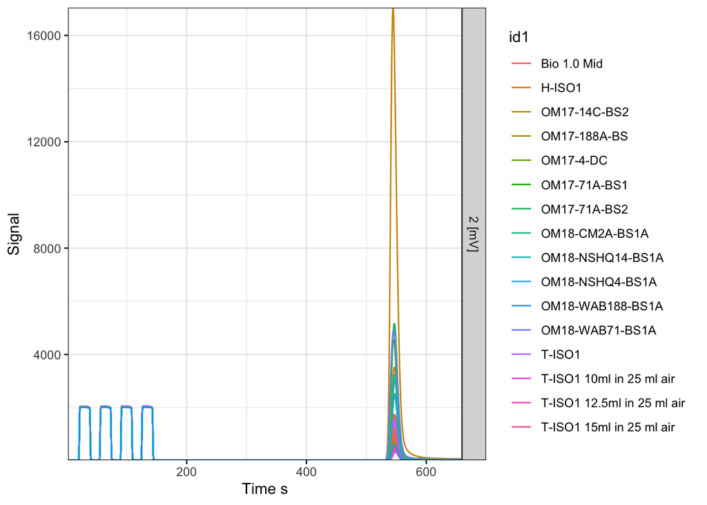

```r
# plot the chromatograms
chroms <- iso_files %>%
  iso_plot_continuous_flow_data(
     # select data and aesthetics
    data = c(2),
    color = id1
  )

# print
chroms
```

## 4.2 Peak maps

```r
# set peak map
peak_maps <-
  tibble::tribble(
    ~compound, ~ref_nr, ~`rt`,
    # peak map data (row-by-row)
    "H2",          1,      29,
    "H2",          2,      64,
    "H2",          3,      100,
    "H2",          4,      130,
    "CH4",          NA,     547
  )

# print
peak_maps %>% knitr::kable(digits = 0)
```

| compound | ref_nr | rt |
| --- | --- | --- |
| H2 | 1 | 29 |
| H2 | 2 | 64 |
| H2 | 3 | 100 |
| H2 | 4 | 130 |
| CH4 | NA | 547 |

## 4.3 Fetch peak table

```r
# identify peaks
peak_table_w_ids <- iso_files %>%
  iso_map_peaks(peak_maps) %>%
  # peak table
  iso_get_peak_table(include_file_info = everything())
```

```
## Info: 270 of 271 peaks in 54 files were successfully mapped using a single peak map. 1 peak(s) could not be mapped.
```

```
## Info: aggregating peak table from 54 data file(s), including file info 'everything()'
```

Display an example chromatogram for CH$_4$.

```r
chrom_mapped <- iso_files %>%
  iso_filter_files(id1 == "OM18-CM2A-BS1A") %>%
  iso_plot_continuous_flow_data(
    # select data and aesthetics
    data = c(2),
    color = id1,
    # provide our peak table with ids
    peak_table = peak_table_w_ids,
    # define peak labels, this can be any valid expression
    peak_label = iso_format(id = peak_info),
    # specify which labels to show (removing the !is_identified or putting a
    # restriction by retention time can help a lot with busy chromatograms)
    peak_label_filter = is_identified | !is_identified | is_missing
  )+
  theme(legend.position = "bottom")
```

```
## Info: applying file filter, keeping 1 of 54 files
```

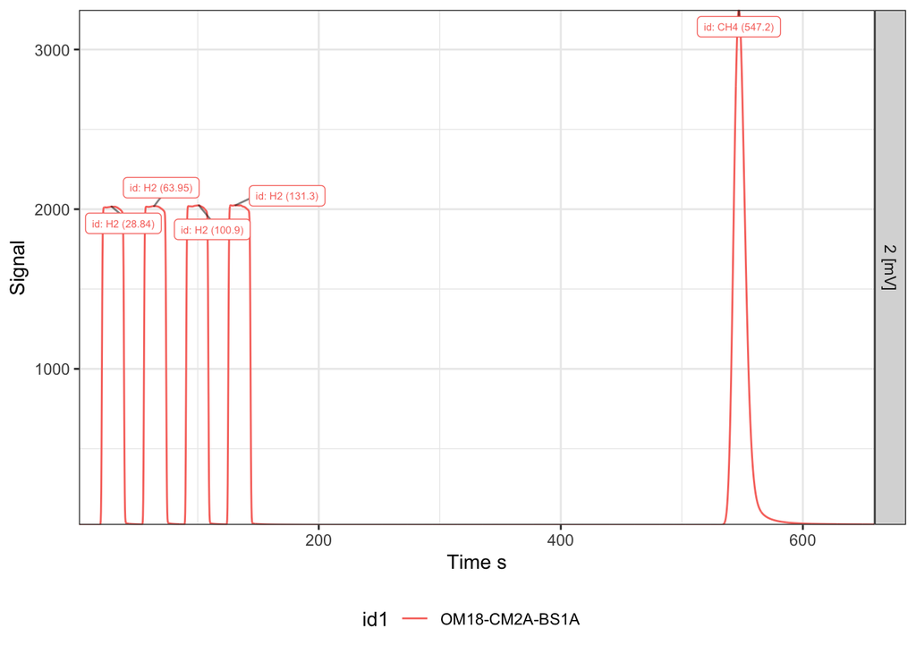

```r
chrom_mapped
```

## 4.4 Select analyte peaks

```r
# focus on analyte peaks
peak_table_analytes <- peak_table_w_ids %>%
  filter(compound == "CH4")

 # We separately tested and determined the limit of quantitation (defined here as amplitude yielding dD sample standard deviation of 9 per mil over studied amplitude range) for our intrument setup.

peak_table_analytes <- peak_table_analytes %>%
filter(amp2 > 1000)

# print
peak_table_analytes
```

| file_id | file_root | file_path | file_subpath | file_datetime | file_size | Row | Peak Center | Check Ref. Dilution | H3 Stability | H3 Factor | Conditioning | Seed Oxidation | GC Method | AS Method | id1 | inject_type | Analysis | Comment | Method | measurement_info | MS_integration_time.s | inject_volume | folder | compound | peak_info | ref_nr | peak_nr | is_ref | rt_start | … |
| --- | --- | --- | --- | --- | --- | --- | --- | --- | --- | --- | --- | --- | --- | --- | --- | --- | --- | --- | --- | --- | --- | --- | --- | --- | --- | --- | --- | --- | --- | --- |
| 1341__T-ISO1_1000.dxf | . | data_raw/OM17-18_CH4_H_data/OM17-18_CH4_H_dxf_files/1341__T-ISO1_1000.dxf | NA | 2018-06-26 12:26:48 | 237310 | 13 | 1 | 0 | 0 | 7.93812064911777 | 0 | 0 | OGL Testing\\DBN\\180624 GC CP 30m CH C1 gases SSL splitless 660s 27C isothermal injector 70C 0.6 ml min.tr2.meth | Disabled | T-ISO1 | lin.std | 1341 | 1000 | OGL Testing\\DBN\\180624 MS CP 30m H CH4 manual 660s acquisition BF 190-465s enter start.met |  | 0.2 | 1000 | OM17-18_CH4_H_dxf_files | CH4 | CH4 (547) | NA | 5 | 0 | 531.487 | … |
| 1342__T-ISO1_0900.dxf | . | data_raw/OM17-18_CH4_H_data/OM17-18_CH4_H_dxf_files/1342__T-ISO1_0900.dxf | NA | 2018-06-26 13:09:54 | 237270 | 14 | 1 | 0 | 0 | 7.93812064911777 | 0 | 0 | OGL Testing\\DBN\\180624 GC CP 30m CH C1 gases SSL splitless 660s 27C isothermal injector 70C 0.6 ml min.tr2.meth | Disabled | T-ISO1 | lin.std | 1342 | 0900 | OGL Testing\\DBN\\180624 MS CP 30m H CH4 manual 660s acquisition BF 190-465s enter start.met |  | 0.2 | 900 | OM17-18_CH4_H_dxf_files | CH4 | CH4 (547.2) | NA | 5 | 0 | 532.323 | … |
| 1343__T-ISO1_0800.dxf | . | data_raw/OM17-18_CH4_H_data/OM17-18_CH4_H_dxf_files/1343__T-ISO1_0800.dxf | NA | 2018-06-26 13:23:11 | 237310 | 15 | 1 | 0 | 0 | 7.93812064911777 | 0 | 0 | OGL Testing\\DBN\\180624 GC CP 30m CH C1 gases SSL splitless 660s 27C isothermal injector 70C 0.6 ml min.tr2.meth | Disabled | T-ISO1 | lin.std | 1343 | 0800 | OGL Testing\\DBN\\180624 MS CP 30m H CH4 manual 660s acquisition BF 190-465s enter start.met |  | 0.2 | 800 | OM17-18_CH4_H_dxf_files | CH4 | CH4 (547.2) | NA | 5 | 0 | 532.532 | … |
| 1344__T-ISO1_0700.dxf | . | data_raw/OM17-18_CH4_H_data/OM17-18_CH4_H_dxf_files/1344__T-ISO1_0700.dxf | NA | 2018-06-26 13:39:38 | 237270 | 16 | 1 | 0 | 0 | 7.93812064911777 | 0 | 0 | OGL Testing\\DBN\\180624 GC CP 30m CH C1 gases SSL splitless 660s 27C isothermal injector 70C 0.6 ml min.tr2.meth | Disabled | T-ISO1 | lin.std | 1344 | 0700 | OGL Testing\\DBN\\180624 MS CP 30m H CH4 manual 660s acquisition BF 190-465s enter start.met |  | 0.2 | 700 | OM17-18_CH4_H_dxf_files | CH4 | CH4 (547.4) | NA | 5 | 0 | 532.532 | … |
| 1353__T-ISO1_0950.dxf | . | data_raw/OM17-18_CH4_H_data/OM17-18_CH4_H_dxf_files/1353__T-ISO1_0950.dxf | NA | 2018-06-26 17:20:12 | 237118 | 25 | 1 | 0 | 0 | 7.93812064911777 | 0 | 0 | OGL Testing\\DBN\\180624 GC CP 30m CH C1 gases SSL splitless 660s 27C isothermal injector 70C 0.6 ml min.tr2.meth | Disabled | T-ISO1 | lin.std | 1353 | 0950 | OGL Testing\\DBN\\180624 MS CP 30m H CH4 manual 660s acquisition BF 190-465s enter start.met |  | 0.2 | 950 | OM17-18_CH4_H_dxf_files | CH4 | CH4 (547.2) | NA | 5 | 0 | 532.114 | … |
| 1354__T-ISO1_0850.dxf | . | data_raw/OM17-18_CH4_H_data/OM17-18_CH4_H_dxf_files/1354__T-ISO1_0850.dxf | NA | 2018-06-26 17:34:54 | 237118 | 26 | 1 | 0 | 0 | 7.93812064911777 | 0 | 0 | OGL Testing\\DBN\\180624 GC CP 30m CH C1 gases SSL splitless 660s 27C isothermal injector 70C 0.6 ml min.tr2.meth | Disabled | T-ISO1 | lin.std | 1354 | 0850 | OGL Testing\\DBN\\180624 MS CP 30m H CH4 manual 660s acquisition BF 190-465s enter start.met |  | 0.2 | 850 | OM17-18_CH4_H_dxf_files | CH4 | CH4 (547.2) | NA | 5 | 0 | 532.323 | … |
| 1355__T-ISO1_1000.dxf | . | data_raw/OM17-18_CH4_H_data/OM17-18_CH4_H_dxf_files/1355__T-ISO1_1000.dxf | NA | 2018-06-26 17:47:31 | 240472 | 27 | 1 | 0 | 0 | 7.93812064911777 | 0 | 0 | OGL Testing\\DBN\\180624 GC CP 30m CH C1 gases SSL splitless 660s 27C isothermal injector 70C 0.6 ml min.tr2.meth | Disabled | T-ISO1 | lin.std | 1355 | 1000 | OGL Testing\\DBN\\180624 MS CP 30m H CH4 manual 660s acquisition BF 190-465s enter start.met |  | 0.2 | 1000 | OM17-18_CH4_H_dxf_files | CH4 | CH4 (547) | NA | 5 | 0 | 531.487 | … |
| 1357__T-ISO1_1000.dxf | . | data_raw/OM17-18_CH4_H_data/OM17-18_CH4_H_dxf_files/1357__T-ISO1_1000.dxf | NA | 2018-06-26 18:47:22 | 237118 | 29 | 1 | 0 | 0 | 7.93812064911777 | 0 | 0 | OGL Testing\\DBN\\180624 GC CP 30m CH C1 gases SSL splitless 660s 27C isothermal injector 70C 0.6 ml min.tr2.meth | Disabled | T-ISO1 | lin.std | 1357 | 1000 | OGL Testing\\DBN\\180624 MS CP 30m H CH4 manual 660s acquisition BF 190-465s enter start.met |  | 0.2 | 1000 | OM17-18_CH4_H_dxf_files | CH4 | CH4 (546.5) | NA | 5 | 0 | 531.696 | … |
| 1362__T-ISO1_0750.dxf | . | data_raw/OM17-18_CH4_H_data/OM17-18_CH4_H_dxf_files/1362__T-ISO1_0750.dxf | NA | 2018-06-26 20:28:24 | 237126 | 34 | 1 | 0 | 0 | 7.93812064911777 | 0 | 0 | OGL Testing\\DBN\\180624 GC CP 30m CH C1 gases SSL splitless 660s 27C isothermal injector 70C 0.6 ml min.tr2.meth | Disabled | T-ISO1 | lin.std | 1362 | 0750 | OGL Testing\\DBN\\180624 MS CP 30m H CH4 manual 660s acquisition BF 190-465s enter start.met |  | 0.2 | 750 | OM17-18_CH4_H_dxf_files | CH4 | CH4 (547.2) | NA | 5 | 0 | 532.741 | … |
| 1381__H-ISO1_1000.dxf | . | data_raw/OM17-18_CH4_H_data/OM17-18_CH4_H_dxf_files/1381__H-ISO1_1000.dxf | NA | 2018-06-27 13:33:21 | 237178 | 14 | 1 | 0 | 0 | 8.03765609891788 | 0 | 0 | OGL Testing\\DBN\\180624 GC CP 30m CH C1 gases SSL splitless 660s 27C isothermal injector 70C 0.6 ml min.tr2.meth | Disabled | H-ISO1 | test | 1381 | 1000 | OGL Testing\\DBN\\180624 MS CP 30m H CH4 manual 660s acquisition BF 190-465s enter start.met |  | 0.2 | 1000 | OM17-18_CH4_H_dxf_files | CH4 | CH4 (545.7) | NA | 5 | 0 | 530.860 | … |

[output cut: 20 more lines]

# 5 Isotope standard values

## 5.1 Load isotope standards

```r
standards <-
  tibble::tribble(
    ~id1,             ~true_d2H,
    "T-ISO1",               -157,
    "H-ISO1",               -156,
    "Bio 1.0 Mid",      -240
  ) %>%
  mutate(
    true_d2H = iso_double_with_units(true_d2H, "permil")
  )
standards %>% knitr::kable()
```

| id1 | true_d2H |
| --- | --- |
| T-ISO1 | -157 |
| H-ISO1 | -156 |
| Bio 1.0 Mid | -240 |

## 5.2 Add isotope standards

```r
peak_table_w_stds <-
  peak_table_analytes %>%
  iso_add_standards(stds = standards, match_by = c("id1"))
```

```
## Info: matching standards by 'id1' - added 3 standard entries to 21 out of 30 rows, added new column 'is_std_peak' to identify standard peaks
```

## 5.3 Initial overview plots of data

Plot of standards, accepted versus measured $\delta^{2}\text{H}$. Coefficients and $\text{r}^2$ value of regression reported further below.

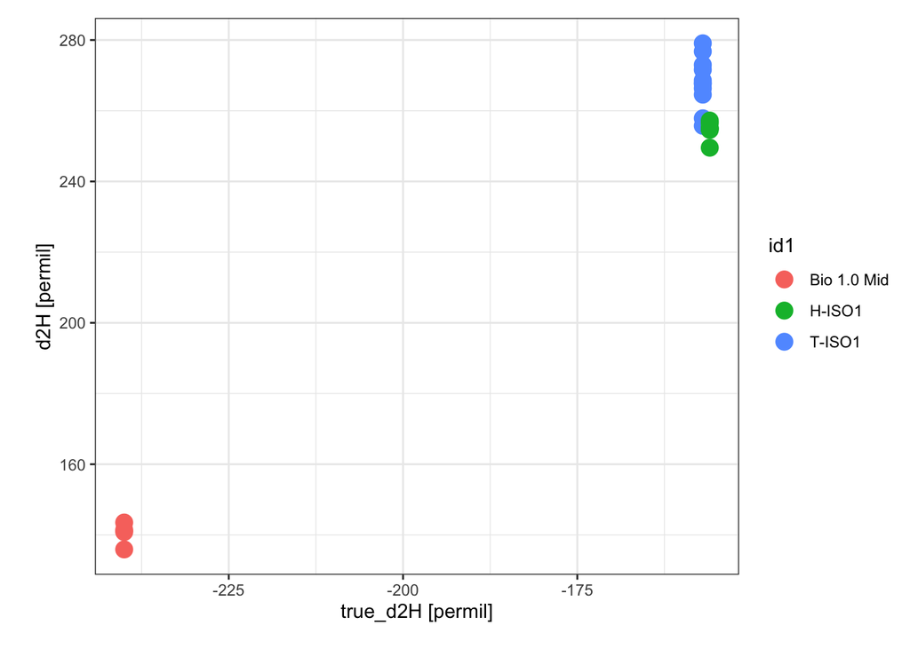

```r
# generate plot
plot_stnds_accepted_measured <- peak_table_w_stds %>% filter(is_std_peak == TRUE) %>%
  # use generic data plot function
  iso_plot_data(
    x = true_d2H,
    y = d2H,
    color = id1,
    points = TRUE
  )

# print
plot_stnds_accepted_measured
```

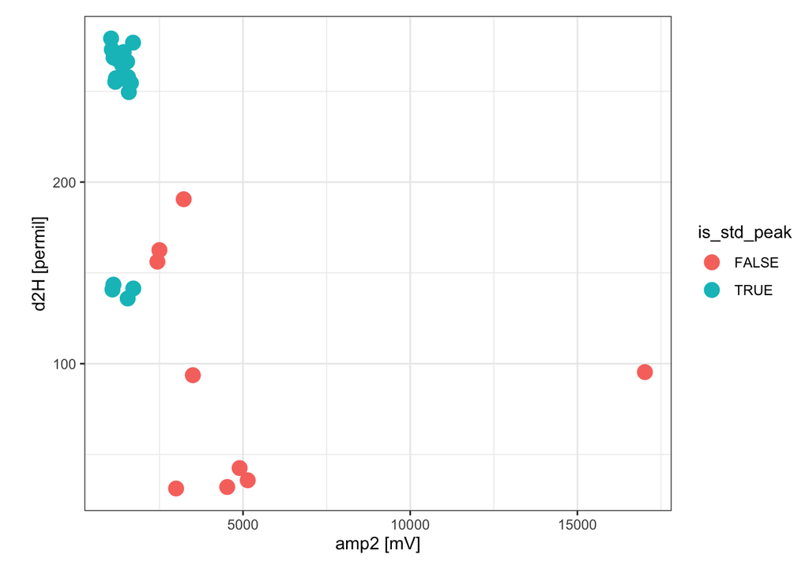

```r
# generate plot
plot_amp_d2H <- peak_table_w_stds %>%
  # use generic data plot function
  iso_plot_data(
    x = amp2, y = d2H, color = is_std_peak,
    points = TRUE
  )

# print
plot_amp_d2H
```

Standards cover most of sample time range. Standard delta analyses appear pretty constant over time.

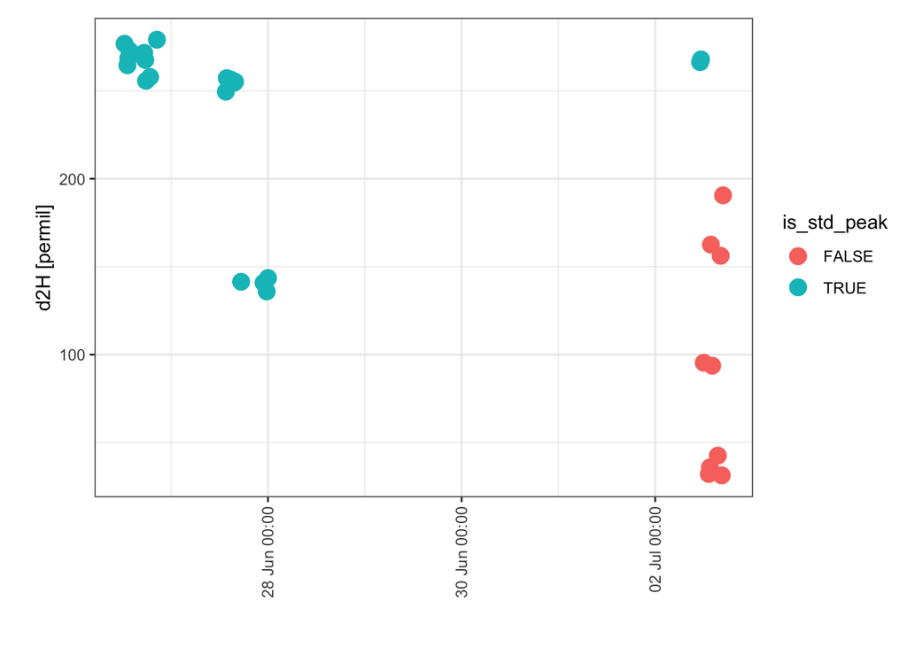

```r
# generate plot
plot_d2H_time <- peak_table_w_stds %>%
  # use generic data plot function
  iso_plot_data(
    x = file_datetime, y = d2H, color = is_std_peak,
    points = TRUE
  )

# print
plot_d2H_time
```

# 6 Calibration

## 6.1 Generate a calibration with linear regression

```r
global_calibs <- peak_table_w_stds %>%
  # prepare for calibration
  iso_prepare_for_calibration() %>%
  # run calibrations
  iso_generate_calibration(
    model = c(
      # reference scale correction
      delta_only = lm(d2H ~ true_d2H)
    ),
    # specify which peaks to include in the calibration, here:
    # - all std_peaks (this filter should always be included!)
    use_in_calib = is_std_peak
  )
```

```
## Info: preparing data for calibration by nesting the entire dataset
```

```
## Info: generating calibration based on 1 model (delta_only = 'lm(d2H ~ true_d2H)') for 1 data group(s) with standards filter 'is_std_peak'. Storing residuals in new column 'resid'. Storing calibration info in new column 'in_calib'.
```

## 6.2 Coefficients

```r
# look at coefficients and summary
global_calibs %>%
  # unnest calibration parameters
  iso_get_calibration_parameters(
    select_from_coefs =
      c(term, estimate, SE = std.error, signif),
    select_from_summary =
      c(fit_R2 = adj.r.squared, fit_RMSD = deviance, residual_df = df.residual)) %>%
  arrange(term) %>%
  knitr::kable(digits = 4)
```

```
## Info: retrieving coefficient column(s) 'c(term, estimate, SE = std.error, signif)' for calibration
```

```
## Info: retrieving summary column(s) 'c(fit_R2 = adj.r.squared, fit_RMSD = deviance, residual_df = df.residual)' for calibration
```

| calib | calib_ok | calib_points | term | estimate | SE | signif | fit_R2 | fit_RMSD | residual_df |
| --- | --- | --- | --- | --- | --- | --- | --- | --- | --- |
| delta_only | TRUE | 21 | (Intercept) | 493.9170 | 10.1767 | *** (p < 0.001) | 0.9699 | 1435.874 | 19 |
| delta_only | TRUE | 21 | true_d2H | 1.4722 | 0.0580 | *** (p < 0.001) | 0.9699 | 1435.874 | 19 |

## 6.3 Visualize Calibration Parameters

The visualization of the calibration parameters reveals that as expected the scale contraction is statistically relevant (`***` = p.value < 0.001).

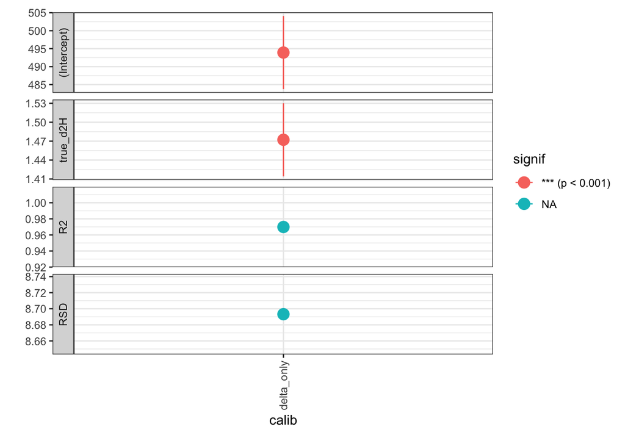

```r
global_calibs %>% iso_plot_calibration_parameters()
```

## 6.4 Apply global calibration

```r
global_calibs_applied <-
  global_calibs %>%
  # which calibration to use? can include multiple if desired to see the result
  # in this case, the amplitude- and time-conscious calibrations are not necessary
  filter(calib == "delta_only") %>%
  # apply calibration indication what should be calculated
  iso_apply_calibration(true_d2H, calculate_error = TRUE)
```

```
## Info: applying calibration to infer 'true_d2H' for 1 data group(s); storing resulting value in new column 'true_d2H_pred' and estimated error in new column 'true_d2H_pred_se'. This may take a moment... finished.
```

```r
# calibration ranges
global_calibs_with_ranges <-
  global_calibs_applied %>%
  # evaluate calibration range for the measured amplitude and predicted d2H
  iso_evaluate_calibration_range(amp2, true_d2H_pred)
```

```
## Info: evaluating range for terms 'amp2' and 'true_d2H_pred' in calibration for 1 data group(s); storing resulting summary for each data entry in new column 'in_range'.
```

```r
# show calibration ranges
global_calibs_with_ranges %>%
  iso_get_calibration_range() %>%
  iso_remove_list_columns() %>%
  knitr::kable(d = 2)
```

```
## Info: retrieving all calibration range information for calibration
```

| calib | calib_ok | calib_points | term | units | min | max |
| --- | --- | --- | --- | --- | --- | --- |
| delta_only | TRUE | 21 | amp2 | mV | 1053.09 | 1718.26 |
| delta_only | TRUE | 21 | true_d2H_pred | permil | -243.18 | -145.93 |

```r
# create calibrated peak table
peak_table_calibrated <- global_calibs_with_ranges %>%
  iso_get_calibration_data()
```

```
## Info: retrieving all data
```

# 7 Inspect Calibration

## 7.1 Overview

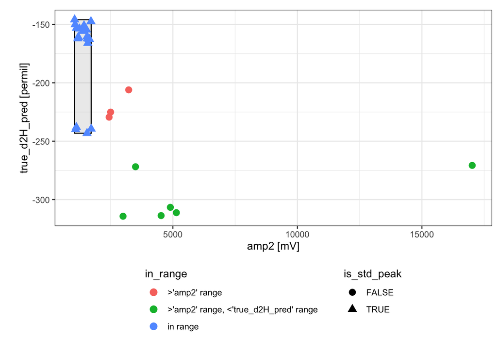

```r
# replicate earlier overview plot but now with the calibrated delta values
# and with a highlight of the calibration ranges and which points are in range
peak_table_calibrated %>%
  # focus on identified peaks (comment out this line to see ALL peaks)
  filter(!is.na(compound)) %>%
  # visualize with convenience function iso_plot_data
  iso_plot_data(
    # choose x and y (multiple y possible)
    x = amp2, y = true_d2H_pred,
    # choose aesthetics
    color = in_range, shape = is_std_peak, label = compound, size = 3,
    # decide what geoms to include
    points = TRUE
  ) %>%
  # highlight calibration range
  iso_mark_calibration_range() +
  # legend
  theme(legend.position = "bottom", legend.direction = "vertical")
```

## 7.2 Summary

```r
# generate data summary
peak_data <-
  peak_table_calibrated %>%
  # focus on identified peaks in the samples
  filter(!is.na(compound))

# summarize replicates
peak_data_summary <-
  peak_data %>%
  # summarize for each sample and compound
  group_by(id1, compound) %>%
  iso_summarize_data_table(amp2, true_d2H_pred, true_d2H_pred_se) %>% select(-`true_d2H_pred_se sd`)

# add column in which d2H is rounded to permil
peak_data_summary <- peak_data_summary %>% mutate(`d2H rounded to integer` = round(`true_d2H_pred mean`, 0))

# print
peak_data_summary %>% iso_make_units_explicit() %>% knitr::kable(d = 2)
```

| id1 | compound | n | amp2 mean [mV] | amp2 sd | true_d2H_pred mean [permil] | true_d2H_pred sd | true_d2H_pred_se mean [permil] | d2H rounded to integer [permil] |
| --- | --- | --- | --- | --- | --- | --- | --- | --- |
| Bio 1.0 Mid | CH4 | 4 | 1371.45 | 311.49 | -240.12 | 2.19 | 6.60 | -240 |
| H-ISO1 | CH4 | 6 | 1401.80 | 227.01 | -162.52 | 1.83 | 6.06 | -163 |
| OM17-14C-BS2 | CH4 | 2 | 10259.28 | 9560.55 | -271.30 | 0.82 | 7.19 | -271 |
| OM17-4-DC | CH4 | 1 | 2499.03 | NA | -225.09 | NA | 6.39 | -225 |
| OM17-71A-BS1 | CH4 | 1 | 4526.81 | NA | -313.70 | NA | 8.21 | -314 |
| OM17-71A-BS2 | CH4 | 1 | 5139.85 | NA | -311.18 | NA | 8.14 | -311 |
| OM18-CM2A-BS1A | CH4 | 1 | 3224.93 | NA | -206.05 | NA | 6.19 | -206 |
| OM18-NSHQ14-BS1A | CH4 | 1 | 2997.66 | NA | -314.25 | NA | 8.23 | -314 |
| OM18-NSHQ4-BS1A | CH4 | 1 | 2438.27 | NA | -229.41 | NA | 6.45 | -229 |
| OM18-WAB71-BS1A | CH4 | 1 | 4897.87 | NA | -306.62 | NA | 8.02 | -307 |
| T-ISO1 | CH4 | 11 | 1375.15 | 220.64 | -153.40 | 4.83 | 6.09 | -153 |

# 8 Export

Save data to xlsx spreadsheet.

```r
# export the global calibration with all its information and data to Excel
peak_table_calibrated %>%
  iso_export_calibration_to_excel(
    filepath = format(Sys.Date(), "data_output/%Y%m%d_OM17-18_CH4_H_data_data_calibrated.xlsx"),
    # include data summary as an additional useful tab
    `data summary` = peak_data_summary
  )
```

```
## Info: exporting calibrations into Excel '20200811_OM17-18_CH4_H_data_data_calibrated.xlsx'...
```

```
## Info: retrieving all data
```

```
## Info: retrieving all coefficient information for calibration
```

```
## Info: retrieving all summary information for calibration
```

```
## Info: retrieving all calibration range information for calibration
```

```
## Info: export complete, created tabs 'data summary', 'all data', 'calib coefs', 'calib summary' and 'calib range'.
```